# Machine Learning Project 3 - Healthcare

### 2.j Use a pair plot to understand the relationship between all the given variables

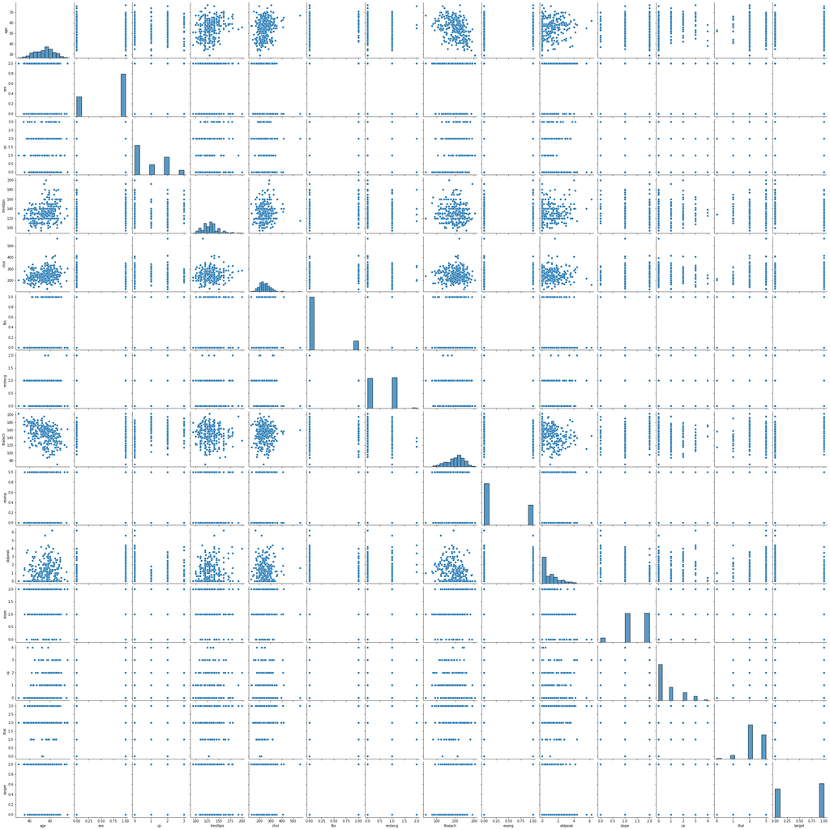

```python
sns.pairplot(data=data)
```

**Observations:** No trends seem to stand out to me

## 3. Build a baseline model to predict the risk of a heart attack using a logistic regression and random forest and explore the results while using correlation analysis and logistic regression (leveraging standard error and p-values from statsmodels) for feature selection

```python
#Importing Logistic Regression model
from sklearn.linear_model import LogisticRegression
from sklearn.model_selection import train_test_split
import statsmodels.api as sm
```

```python
lr = LogisticRegression()
```

```python
X=data.drop(['target'],axis=1)
y=data['target']
y=y.astype('str')
```

```python
statsmodel = sm.OLS(data['target'],X).fit()

for i, val in enumerate(statsmodel.pvalues):
    print(X.columns[i],": ",val)
```

```
age :  0.1340158813305078
sex :  0.00030891823038867606
cp :  2.4070688196864413e-06
trestbps :  0.47953020466911433
chol :  0.7992936464589643
fbs :  0.8895215351247592
restecg :  0.08498150219313842
thalach :  4.8677414344298345e-08
exang :  0.019466505662766417
oldpeak :  0.023711738945244667
slope :  0.03862071555281008
ca :  1.4260916940494457e-06
thal :  0.004462483367446387
```

Based on the p-values we will drop the columns with p-value greater than 0.005

```python
X = X.drop(['age', 'trestbps', 'chol', 'fbs', 'restecg', 'exang', 'oldpeak', 'slope'], axis=1)
```

```python
X_train, X_test, y_train, y_test = train_test_split(X, y, test_size=0.3)
```

```python
lr.fit(X_train,y_train).score(X_train,y_train)
```

```
0.8104265402843602
```

```python
lr.score(X_train,y_train)
```

```
0.8104265402843602
```

```python
lr.score(X_test,y_test)
```

```
0.8461538461538461
```

```python
predictionlr = lr.predict(X_test)
```

### Random Forest

```python
from sklearn.ensemble import RandomForestClassifier
from sklearn.metrics import classification_report, confusion_matrix, accuracy_score
```

```python
model = RandomForestClassifier().fit(X_train, y_train)
predictionforest = model.predict(X_test)
print(confusion_matrix(y_test,predictionforest))
print(classification_report(y_test,predictionforest))
```

```
[[35 11]
 [ 8 37]]
              precision    recall  f1-score   support

           0       0.81      0.76      0.79        46
           1       0.77      0.82      0.80        45

    accuracy                           0.79        91
   macro avg       0.79      0.79      0.79        91
weighted avg       0.79      0.79      0.79        91
```

```python
print(confusion_matrix(y_test,predictionlr))
print(classification_report(y_test,predictionlr))
```

```
[[34 12]
 [ 2 43]]
              precision    recall  f1-score   support

           0       0.94      0.74      0.83        46
           1       0.78      0.96      0.86        45

    accuracy                           0.85        91
   macro avg       0.86      0.85      0.84        91
weighted avg       0.86      0.85      0.84        91
```

**Observations:** The Logistic regression model seems to do a better job at predicting CVD based on the available features. It has higher weighted average precision, recall, and f1-scores. Overall the logistic regression model performs decently well.